# Assignment #3 - Data Mining in R

Bradley Blanchard, bb1852

## Obtaining a Classification Model for a Bank Credit dataset

**Outline**

**Supplemental Analysis** + Description of the German credit dataset + Loading the dataset and installing the necessary packages + Utilization of Random Forest to determine Variable Importance + A Classification Tree for the German credit dataset

**Random Forest (Requirement #1)** + Building the Random Forest Model + The Confusion Matrix for the Random Forest Model + The Error Rate for the Random Forest Model + The Overall Benefit/Cost of the Random Forest Model + A Visualization of (1) Random Forest Model

**Support Vector Machine (SVM) (Requirement #2)** +

**Description of the German credit dataset.**

**1. Title: [German Credit data](https://archive.ics.uci.edu/ml/machine-learning-databases/statlog/german/german.doc)**

**2. Source Information**

```
Professor Dr. Hans Hofmann
Institut f"ur Statistik und "Okonometrie
Universit"at Hamburg
FB Wirtschaftswissenschaften
Von-Melle-Park 5
2000 Hamburg 13
```

**3. Number of Instances: 1000**

**4. Two datasets are provided.** The original dataset, in the form provided by Prof. Hofmann, contains categorical/symbolic attributes and is in the file [“german.data”](https://archive.ics.uci.edu/ml/machine-learning-databases/statlog/german/german.data).

**5. For algorithms that need numerical attributes, Strathclyde University produced the file “german.data-numeric”.**  
This file has been edited and several indicator variables added to make it suitable for algorithms which cannot cope with categorical variables. Severalattributes that are ordered categorical (such as attribute 17) have been coded as integer. This was the form used by StatLog.

**6. Number of Attributes german: 20 (7 numerical, 13 categorical)** Number of Attributes german.numer: 24 (24 numerical)

**7. Attribute description for german**

- **Attribute 1:** (qualitative) Status of existing checking account
  - A11 : … < 0 DM
  - A12 : 0 <= … < 200 DM
  - A13 : … >= 200 DM / salary assignments for at least 1 year
  - A14 : no checking account
- **Attribute 2:** (numerical) Duration in month
- **Attribute 3:** (qualitative) Credit history
  - A30 : no credits taken/all credits paid back duly
  - A31 : all credits at this bank paid back duly
  - A32 : existing credits paid back duly till now
  - A33 : delay in paying off in the past
  - A34 : critical account/other credits existing (not at this bank)
- **Attribute 4:** (qualitative) Purpose
  - A40 : car (new)
  - A41 : car (used)
  - A42 : furniture/equipment
  - A43 : radio/television
  - A44 : domestic appliances
  - A45 : repairs
  - A46 : education
  - A47 : (vacation - does not exist?)
  - A48 : retraining
  - A49 : business
  - A410 : others
- **Attribute 5:** (numerical) Credit amount
- **Attribute 6:** (qualitative) Savings account/bonds
  - A61 : … < 100 DM
  - A62 : 100 <= … < 500 DM
  - A63 : 500 <= … < 1000 DM
  - A64 : .. >= 1000 DM
  - A65 : unknown/ no savings account
- **Attribute 7:** (qualitative) Present employment since
  - A71 : unemployed
  - A72 : … < 1 year
  - A73 : 1 <= … < 4 years
  - A74 : 4 <= … < 7 years
  - A75 : .. >= 7 years
- **Attribute 8:** (numerical) Installment rate in percentage of disposable income
- **Attribute 9:** (qualitative) Personal status and sex
  - A91 : male : divorced/separated
  - A92 : female : divorced/separated/married
  - A93 : male : single
  - A94 : male : married/widowed
  - A95 : female : single
- **Attribute 10:** (qualitative) Other debtors / guarantors
  - A101 : none
  - A102 : co-applicant
  - A103 : guarantor
- **Attribute 11:** (numerical) Present residence since
- **Attribute 12:** (qualitative) Property
  - A121 : real estate
  - A122 : if not A121 : building society savings agreement/life insurance
  - A123 : if not A121/A122 : car or other, not in attribute 6
  - A124 : unknown / no property
- **Attribute 13:** (numerical) Age in years
- **Attribute 14:** (qualitative) Other installment plans
  - A141 : bank
  - A142 : stores
  - A143 : none
- **Attribute 15:** (qualitative) Housing
  - A151 : rent
  - A152 : own
  - A153 : for free
- **Attribute 16:** (numerical) Number of existing credits at this bank
- **Attribute 17:** (qualitative) Job
  - A171 : unemployed/ unskilled - non-resident
  - A172 : unskilled - resident
  - A173 : skilled employee / official
  - A174 : management/ self-employed/highly qualified employee/ officer
- **Attribute 18:** (numerical) Number of people being liable to provide maintenance for
- **Attribute 19:** (qualitative) Telephone
  - A191 : none
  - A192 : yes, registered under the customers name
- **Attribute 21:** (qualitative) foreign worker
  - A201 : yes
  - A202 : no

**8. Cost Matrix**

This dataset requires use of a cost matrix (see below)

```r
costMatrix <- matrix(c(0,5,1,0),ncol=2)
colnames(costMatrix) <- c('Predict Good','Predict Bad')
rownames(costMatrix) <- c('Actual Good','Actual Bad')
```

|  | Predict Good | Predict Bad |
| --- | --- | --- |
| Actual Good | 0 | 1 |
| Actual Bad | 5 | 0 |

(1 = Good, 2 = Bad)

The rows represent the actual classification and the columns the predicted classification.

```
**It is worse to class a customer as good when they are bad (5), than it is to class a customer as bad when they are good (1).**
```

**Load the German Credit dataset and the necessary packages**

```
## Copyright M. P. Wand 1997-2009
```

**Utilization of Random Forest to determine Variable Importance**

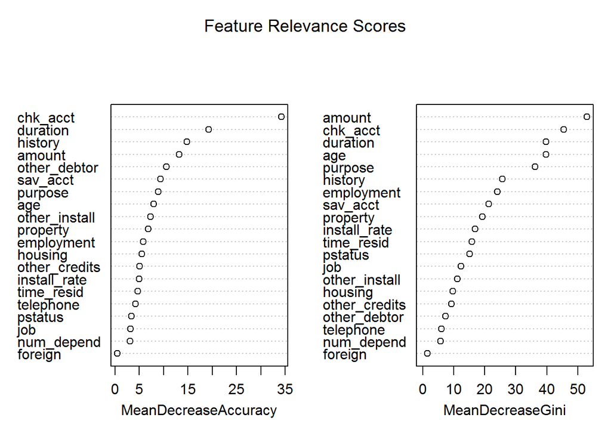

|  | MeanDecreaseAccuracy | MeanDecreaseGini |
| --- | --- | --- |
| chk_acct | 34.197 | 45.432 |
| duration | 19.263 | 39.800 |
| history | 14.765 | 25.718 |
| purpose | 8.926 | 36.170 |
| amount | 13.196 | 52.916 |
| sav_acct | 9.393 | 21.216 |
| employment | 5.846 | 24.054 |
| install_rate | 5.000 | 16.830 |
| pstatus | 3.392 | 15.128 |
| other_debtor | 10.570 | 7.390 |
| time_resid | 4.704 | 15.836 |
| property | 6.819 | 19.271 |
| age | 7.951 | 39.791 |
| other_install | 7.370 | 11.201 |
| housing | 5.533 | 9.647 |
| other_credits | 5.061 | 9.178 |
| job | 3.257 | 12.381 |
| num_depend | 3.135 | 5.771 |
| telephone | 4.249 | 6.062 |
| foreign | 0.509 | 1.514 |

**A Classification Tree for the German credit dataset** Utilizing the ‘rpart’ and ‘rattle’ packages

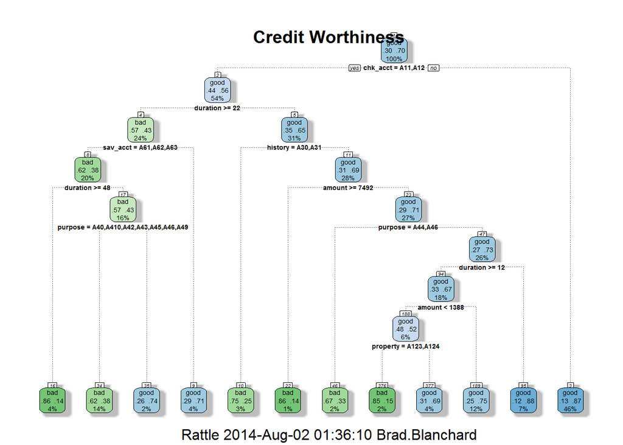

## Random Forest (Requirement #1)

**Building the Random Forest Model**

```r
load('germanCredit.Rdata')
set.seed(1234)
trPerc <- 0.7
sp <- sample(1:nrow(german),as.integer(trPerc*nrow(german)))
tr <- german[sp,]
ts <- german[-sp,]
m <- randomForest(response ~ ., tr, ntree = 3000)
ps <- predict(m, ts)
```

**Predicting with the Random Forest Model**

```
##    4    5    7    8   11   15   16   20   24   28   29   33   34   38   41
## good  bad good good  bad  bad  bad good good good good good good good good
##   42   44   46   47   48   51   52   53   56   57   58   60   62   64   66
## good good good good good good good good good good good  bad good  bad good
##   73   76   77   79   80   87   88   93   98  100  103  107  108  112  118
## good good  bad good good good good good good good good good good good good
##  121  124  125  129  134  136  137  138  140  142  143  144  147  150  153
## good good good good good good good good good  bad good good good good  bad
##  159  161  164  168  173  177  179  187  188  191  203  205  207  208  212
## good good good good good good good good good good good good good good good
##  213  216  218  219  226  227  229  232  234  236  237  239  241  251  253
## good good  bad  bad  bad good good good good good good good  bad good  bad
##  256  259  260  262  264  265  267  286  287  290  301  303  314  318  319
## good good good good good good good  bad  bad  bad good good good good good
##  325  326  328  329  334  336  337  338  340  351  358  359  364  365  370
## good good good good good good good good  bad good good good good good good
##  372  383  385  387  404  406  407  408  410  424  425  428  429  432  437
## good good good good good good good good good good good good good  bad good
##  441  444  445  455  456  460  465  468  469  482  486  495  497  498  499
## good good  bad good good good good good good  bad good good  bad good good
##  505  511  517  519  521  523  525  540  553  556  557  560  561  562  564
##  bad good good good good  bad good good good good  bad good good good good
##  567  568  570  571  572  574  575  577  585  588  594  598  600  605  608
## good good  bad  bad good  bad good good good good  bad good good good good
##  610  619  625  628  630  632  633  639  644  648  650  651  654  658  659
## good good good good good  bad good good good good  bad  bad good good  bad
##  664  666  670  671  675  676  678  683  684  689  692  696  697  701  704
## good good good good good good  bad good good good good good good good good
##  706  710  712  714  723  725  729  730  731  737  739  740  741  744  745
## good good  bad good  bad good  bad good good  bad good  bad good good  bad
##  747  750  752  756  759  760  763  767  775  782  790  793  795  797  802
## good good  bad  bad good good good good good good  bad good good good good
##  816  822  826  829  831  839  841  846  849  851  855  859  863  864  866
##  bad good  bad good good good  bad good good good good good good good good
##  870  878  879  880  882  884  885  889  891  893  894  901  908  910  915
##  bad good good good good good good good good good good good good good  bad
##  922  923  924  925  926  928  929  933  934  936  937  938  939  940  941
## good good good good  bad  bad good good good good good good  bad good good
##  945  947  956  962  968  971  976  978  980  981  984  993  994  995 1000
## good good good good good good good good  bad good good good  bad good good
## Levels: bad good
```

**The Confusion Matrix for the Random Forest Model**

```r
confuseRF <- table(ps,ts$response)
colnames(confuseRF) <- c('Predict Good','Predict Bad')
rownames(confuseRF) <- c('Actual Good','Actual Bad')
```

[output not shown]

**The Error Rate of the Random Forest Model** The Error Rate measures the proportion of the predictions that are incorrect.

```r
err <- 100 * (1 - sum(diag(confuseRF))/sum(confuseRF))
err
```

```
## [1] 27.33
```

**The Overall Benefit/Cost of the Random Forest Model** Calculated by multiplying the Confusion Matrix by the Cost/Benfit Matrix

```r
utilityRF <- sum(confuseRF*costMatrix)
utilityRF
```

```
## [1] 338
```

**A Visualization of (1) Random Forest Model**

```r
tree <- getTree(m,1,labelVar=TRUE)
```

| left daughter | right daughter | split var | split point | status | prediction |
| --- | --- | --- | --- | --- | --- |
| 2 | 3 | property | 3.0 | 1 | NA |
| 4 | 5 | pstatus | 3.0 | 1 | NA |
| 6 | 7 | age | 29.5 | 1 | NA |
| 8 | 9 | chk_acct | 1.0 | 1 | NA |
| 10 | 11 | sav_acct | 12.0 | 1 | NA |
| 12 | 13 | employment | 15.0 | 1 | NA |
| 14 | 15 | chk_acct | 3.0 | 1 | NA |
| 16 | 17 | purpose | 42.0 | 1 | NA |
| 18 | 19 | sav_acct | 12.0 | 1 | NA |
| 0 | 0 | NA | 0.0 | -1 | good |
| 20 | 21 | foreign | 1.0 | 1 | NA |
| 22 | 23 | sav_acct | 1.0 | 1 | NA |
| 24 | 25 | pstatus | 3.0 | 1 | NA |
| 26 | 27 | sav_acct | 9.0 | 1 | NA |
| 28 | 29 | sav_acct | 8.0 | 1 | NA |
| 30 | 31 | amount | 2609.0 | 1 | NA |
| 32 | 33 | age | 64.0 | 1 | NA |
| 0 | 0 | NA | 0.0 | -1 | good |
| 34 | 35 | age | 25.5 | 1 | NA |
| 36 | 37 | time_resid | 2.5 | 1 | NA |
| 0 | 0 | NA | 0.0 | -1 | good |
| 38 | 39 | job | 6.0 | 1 | NA |
| 40 | 41 | other_credits | 3.5 | 1 | NA |
| 0 | 0 | NA | 0.0 | -1 | good |
| 42 | 43 | history | 1.0 | 1 | NA |
| 44 | 45 | telephone | 1.0 | 1 | NA |
| 46 | 47 | other_install | 1.0 | 1 | NA |
| 0 | 0 | NA | 0.0 | -1 | bad |
| 48 | 49 | amount | 9492.5 | 1 | NA |
| 50 | 51 | employment | 9.0 | 1 | NA |

[output cut: 233 more lines]

## Support Vector Machine (SVM) (Requirement #2)

**Building the SVM**

```r
load('germanCredit.Rdata')
trPerc <- 0.7
sp <- sample(1:nrow(german),as.integer(trPerc*nrow(german)))
tr <- german[sp,]
ts <- german[-sp,]

s <- svm(response ~ ., german)
ps <- predict(s,ts)
```

**Predicting with the SVM**

```
##    1    3    5    6    8   11   17   24   31   34   36   43   44   48   50
## good good  bad good good good good good good good  bad good good good good
##   58   63   66   67   68   70   72   73   80   82   83   86   90   93   95
## good good good good good good good good good good good good good good good
##   96  102  105  106  109  112  113  117  121  124  127  128  129  133  134
##  bad good good good good good good  bad good good good good good good good
##  135  138  145  146  150  151  153  156  157  158  161  165  172  174  175
## good good good  bad good good good good good good good good good good good
##  176  178  179  181  184  189  195  198  204  209  210  223  225  231  235
## good good good good good good  bad  bad good good good good good good good
##  236  237  240  242  243  245  250  251  253  260  262  266  271  275  279
##  bad  bad good good  bad good good good  bad good good good good  bad good
##  280  285  289  290  292  296  297  302  303  304  305  306  307  308  314
## good good good  bad good  bad good good good good good good good good good
##  315  316  318  321  324  325  337  340  343  344  347  354  358  361  363
## good  bad good good good good good good good good good  bad good good good
##  368  373  375  377  378  380  381  394  400  402  403  406  409  414  415
## good good  bad good good good good good good good good good good good good
##  416  417  418  421  424  428  429  439  447  448  452  453  454  460  464
## good good good good good good good good  bad good good good good good good
##  469  471  472  473  474  475  478  481  482  487  491  499  503  504  506
## good good  bad good good good good good good good good good good good good
##  508  509  510  513  518  522  527  530  537  542  543  546  548  557  565
## good good good good good good good good good good good  bad good good good
##  566  567  569  573  575  579  582  583  585  592  600  601  608  611  612
## good good good good good  bad good good good good good good  bad good good
##  613  616  618  619  624  627  632  644  647  650  651  659  660  661  663
##  bad good good good good good  bad good good  bad  bad good good good good
##  665  667  669  671  673  675  676  678  681  684  685  693  694  700  705
## good good good good good good good  bad good good good good good good good
##  709  710  716  717  718  725  728  734  749  751  753  756  765  773  776
## good good good good good good  bad good good good good  bad good good  bad
##  780  782  787  791  792  794  795  806  807  808  821  826  829  832  834
## good good good good good good good  bad good good good good good  bad good
##  837  840  844  846  852  853  864  869  871  878  879  883  884  886  887
## good good good good good good good good good good good good good  bad good
##  892  894  899  900  901  903  906  909  910  913  929  932  933  935  936
## good good good good good good good good good good good good good good  bad
##  948  949  954  956  959  968  969  972  974  981  984  995  998  999 1000
## good good  bad good good good good good  bad good good good good  bad good
## Levels: bad good
```

**The Confusion Matrix for the SVM**

```r
confuseSVM <- table(ps,ts$response)
colnames(confuseSVM) <- c('Predict Good','Predict Bad')
rownames(confuseSVM) <- c('Actual Good','Actual Bad')
```

[output not shown]

**The Error Rate of the SVM** The Error Rate measures the proportion of the predictions that are incorrect.

```r
mc <- table(ps, ts$response)
erro <- 100 * (1-sum(diag(mc))/sum(mc))
erro
```

```
## [1] 20
```

**The Overall Benefit/Cost of the SVM** Calculated by multiplying the Confusion Matrix by the Cost/Benfit Matrix

```r
utilitySVM <- sum(confuseSVM*costMatrix)
utilitySVM
```

```
## [1] 288
```

## Comparing the Models (Requirement 3)

**SVM using the performanceEstimation package**

```r
load('germanCredit.Rdata')
svm1 <- performanceEstimation(
  PredTask(response ~ ., german),
  workflowVariants("standardWF", learner="svm",
                   learner.pars=list(cost=c(1,10),
                                   gamma=c(0.1,0.01))),
  HldSettings(nReps=5,hldSz=0.3))
```

```
##
##
## ##### PERFORMANCE ESTIMATION USING  HOLD OUT  #####
##
## ** PREDICTIVE TASK :: german
##
## ++ MODEL/WORKFLOW :: standardWF  variant ->  svm.v1
##
##  5 x 70 %/ 30 % Holdout run with seed =  1234
## Repetition :  1  2  3  4  5
##
##
## ++ MODEL/WORKFLOW :: standardWF  variant ->  svm.v2
##
##  5 x 70 %/ 30 % Holdout run with seed =  1234
## Repetition :  1  2  3  4  5
##
##
## ++ MODEL/WORKFLOW :: standardWF  variant ->  svm.v3
##
##  5 x 70 %/ 30 % Holdout run with seed =  1234
## Repetition :  1  2  3  4  5
##
##
## ++ MODEL/WORKFLOW :: standardWF  variant ->  svm.v4
##
##  5 x 70 %/ 30 % Holdout run with seed =  1234
## Repetition :  1  2  3  4  5
```

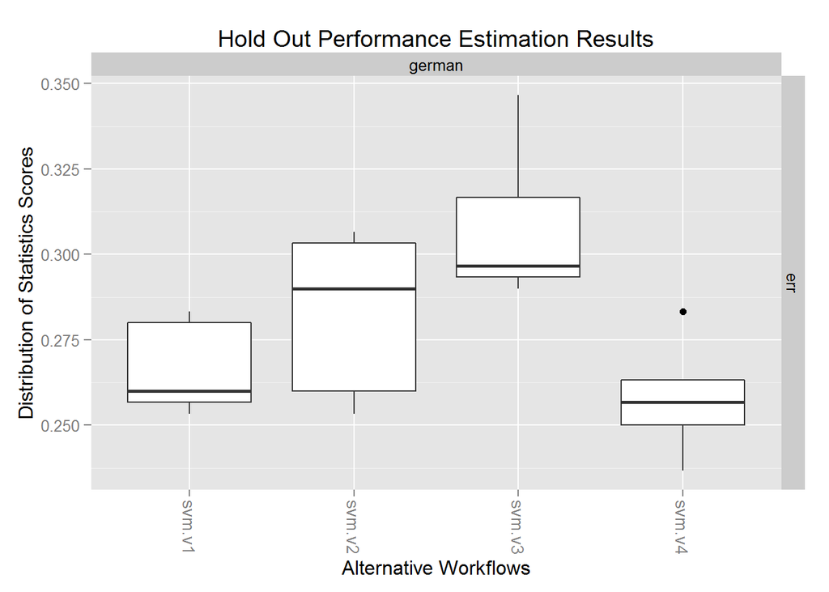

```r
plot(svm1)
```

**Random Forest Model using the performanceEstimation package**

```r
library(performanceEstimation)

load('germanCredit.Rdata')
rf1 <- performanceEstimation(
  PredTask(response ~ ., german),
  workflowVariants("standardWF", learner="randomForest",
                   learner.pars=list(cost=c(1,10),
                                     gamma=c(0.1,0.01))),
  HldSettings(nReps=5,hldSz=0.3))
```

```
##
##
## ##### PERFORMANCE ESTIMATION USING  HOLD OUT  #####
##
## ** PREDICTIVE TASK :: german
##
## ++ MODEL/WORKFLOW :: standardWF  variant ->  randomForest.v1
##
##  5 x 70 %/ 30 % Holdout run with seed =  1234
## Repetition :  1  2  3  4  5
##
##
## ++ MODEL/WORKFLOW :: standardWF  variant ->  randomForest.v2
##
##  5 x 70 %/ 30 % Holdout run with seed =  1234
## Repetition :  1  2  3  4  5
##
##
## ++ MODEL/WORKFLOW :: standardWF  variant ->  randomForest.v3
##
##  5 x 70 %/ 30 % Holdout run with seed =  1234
## Repetition :  1  2  3  4  5
##
##
## ++ MODEL/WORKFLOW :: standardWF  variant ->  randomForest.v4
##
##  5 x 70 %/ 30 % Holdout run with seed =  1234
## Repetition :  1  2  3  4  5
```

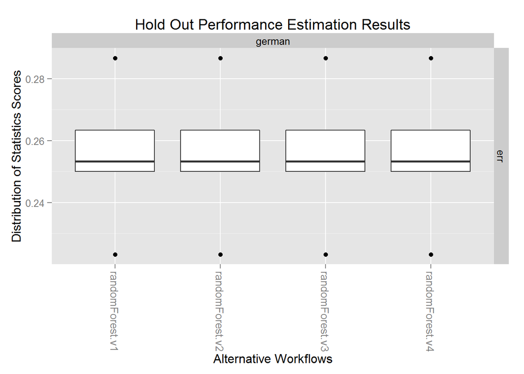

```r
plot(rf1)
```

**Comparing both models using the performanceEstimation package**

```r
load('germanCredit.Rdata')
result <- performanceEstimation(
  c(PredTask(response ~ ., german), PredTask(response ~ ., german)),
  c(workflowVariants("standardWF", learner="svm",
                     learner.pars=list(cost=c(1,10),
                                       gamma=c(0.1,0.01))),
    workflowVariants("standardWF", learner="randomForest",
                     learner.pars=list(se=c(0,0.5,1)),
                     predictor.pars=list(type="class"))),
  HldSettings(nReps=5,hldSz=0.3))
```

```
##
##
## ##### PERFORMANCE ESTIMATION USING  HOLD OUT  #####
##
## ** PREDICTIVE TASK :: german
##
## ++ MODEL/WORKFLOW :: standardWF  variant ->  svm.v1
##
##  5 x 70 %/ 30 % Holdout run with seed =  1234
## Repetition :  1  2  3  4  5
##
##
## ++ MODEL/WORKFLOW :: standardWF  variant ->  svm.v2
##
##  5 x 70 %/ 30 % Holdout run with seed =  1234
## Repetition :  1  2  3  4  5
##
##
## ++ MODEL/WORKFLOW :: standardWF  variant ->  svm.v3
##
##  5 x 70 %/ 30 % Holdout run with seed =  1234
## Repetition :  1  2  3  4  5
##
##
## ++ MODEL/WORKFLOW :: standardWF  variant ->  svm.v4
##
##  5 x 70 %/ 30 % Holdout run with seed =  1234
## Repetition :  1  2  3  4  5
##
##
## ++ MODEL/WORKFLOW :: standardWF  variant ->  randomForest.v1
##
##  5 x 70 %/ 30 % Holdout run with seed =  1234
## Repetition :  1  2  3  4  5
##
##
## ++ MODEL/WORKFLOW :: standardWF  variant ->  randomForest.v2
##
##  5 x 70 %/ 30 % Holdout run with seed =  1234
## Repetition :  1  2  3  4  5
```

[output cut: 35 more lines]

```
##
##  5 x 70 %/ 30 % Holdout run with seed =  1234
## Repetition :  1  2  3  4  5
##
##
## ++ MODEL/WORKFLOW :: standardWF  variant ->  randomForest.v2
##
##  5 x 70 %/ 30 % Holdout run with seed =  1234
## Repetition :  1  2  3  4  5
##
##
## ++ MODEL/WORKFLOW :: standardWF  variant ->  randomForest.v3
##
##  5 x 70 %/ 30 % Holdout run with seed =  1234
## Repetition :  1  2  3  4  5
```

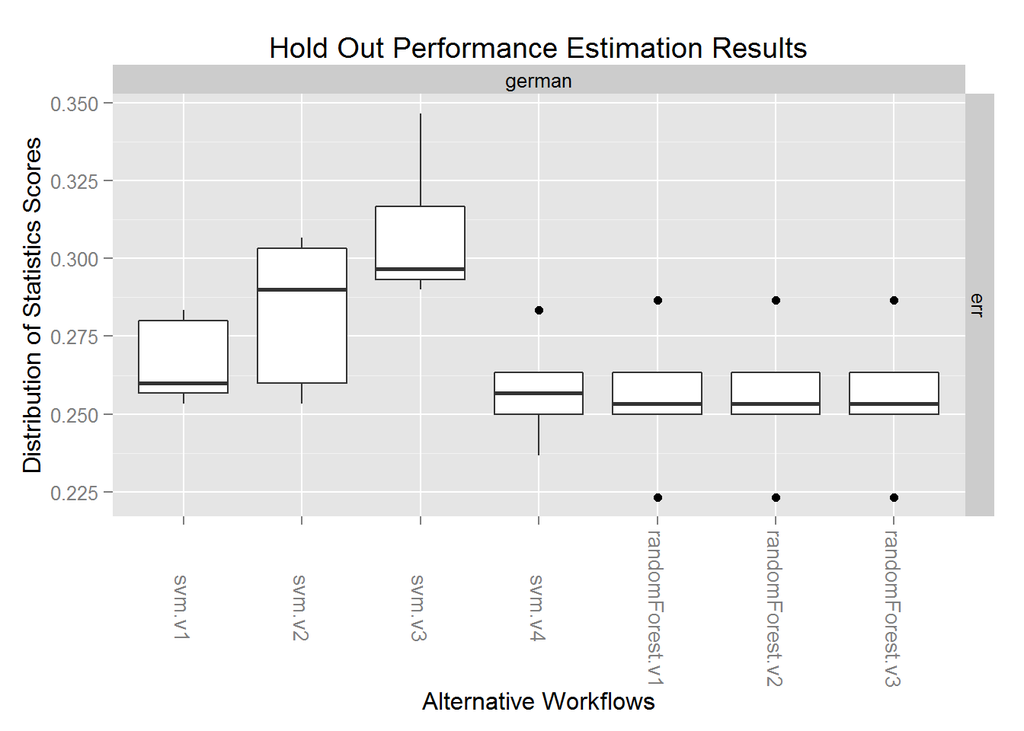

```
## $german
##            Workflow Estimate
## err randomForest.v1    0.255
##
## $german
##            Workflow Estimate
## err randomForest.v1    0.255
```

```
## Workflow Object:
##  Workflow ID       ::  randomForest.v1
##  Workflow Function ::  standardWF
##      Parameter values:
##       learner.pars  ->  se=0
##       predictor.pars  ->  type=class
##       learner  ->  randomForest
```

```r
plot(result)
```